# PI-02 slides

## ANAISIS DE DATOS S&P500 - NELSON FABIAN RODRIGUEZ

### Comenzamos calculando:

#### - El retorno intradiario

#### - El retorno por gap

#### - Las variaciones

#### - La volatilidad

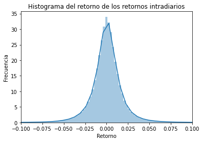

```python
#graficamos el histograma del retorno de los retornos intradiarios
fig = plt.figure()
ax = plt.axes()
sns.distplot(df_precios["Ret_Intradiario"], bins=500)
plt.xlim(-0.1, 0.1)
plt.title('Histograma del retorno de los retornos intradiarios')
plt.xlabel('Retorno')
plt.ylabel('Frecuencia')
plt.show()
```

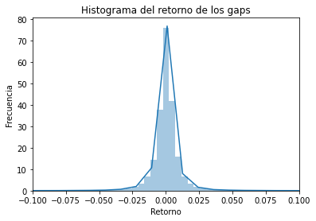

```python
#graficamos el histograma del retorno de los gaps
fig = plt.figure()
ax = plt.axes()
sns.distplot(df_precios["Ret_Gaps"], bins=500)
plt.xlim(-0.1, 0.1)
plt.title('Histograma del retorno de los gaps')
plt.xlabel('Retorno')
plt.ylabel('Frecuencia')
plt.show()
```

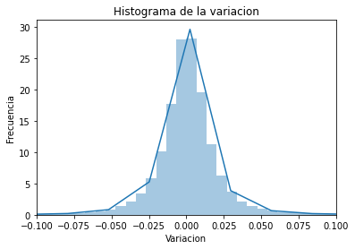

```python
#graficamos el histograma de la variacion
fig = plt.figure()
ax = plt.axes()
sns.distplot(df_precios["Variacion"], bins=800)
plt.xlim(-0.1, 0.1)
plt.title('Histograma de la variacion')
plt.xlabel('Variacion')
plt.ylabel('Frecuencia')
plt.show()
```

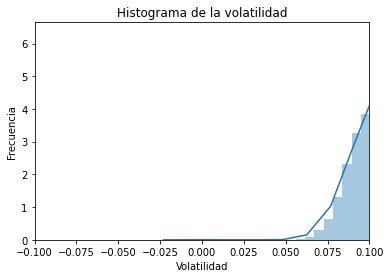

```python
#graficamos el histograma de la volatilidad
fig = plt.figure()
ax = plt.axes()
sns.distplot(df_precios["Volatilidad"], bins=500)
plt.xlim(-0.1, 0.1)
plt.title('Histograma de la volatilidad')
plt.xlabel('Volatilidad')
plt.ylabel('Frecuencia')
plt.show()
```

#### A diferencia de las demas caracteristicas que calculamos, podemos observar que la volatilidad esta sesgada a la derecha.

## Cual es el mejor día para invertir, teniendo en cuenta el retorno de los movimiento gap.

```python
#calculamos la media de los retornos agrupando los dias de la semana en un dataframe nuevo para poder graficar
df_Ret_Gap = df_precios.groupby(['Dia_Semana'])['Ret_Gaps'].mean().reset_index()
```

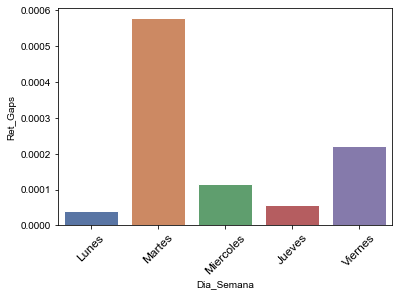

```python
#grafico de los retorno de los movimientos gap en los dias de la semana
plt.xticks(fontsize=12, rotation=45)
sns.set(rc={'figure.figsize':(10,10)})
sns.barplot(x='Dia_Semana', y='Ret_Gaps', data=df_Ret_Gap)
plt.show()
```

## Cual es el mejor día para invertir, teniendo en cuenta el retorno de los movimientos intradiarios.

```python
#calculamos el retorno intradiario agrupado por dias de la semana
df_Ret_Intra = df_precios.groupby('Dia_Semana')['Ret_Intradiario'].mean().reset_index()

#Agregamos una columna de los dias de la semana
df_Ret_Intra['Dia_Semana'] = dias_semana
```

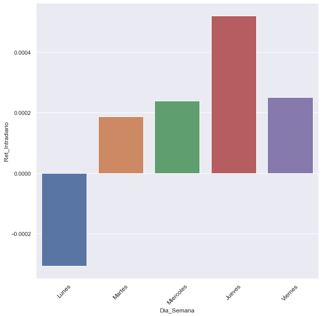

```python
#grafico de los retorno de los movimientos intradiarios en los dias de la semana
plt.xticks(fontsize=12, rotation=45)
sns.set(rc={'figure.figsize':(10,10)})
sns.barplot(x='Dia_Semana', y='Ret_Intradiario', data=df_Ret_Intra)
plt.show()
```

#### CONCLUSION: El mejor dia para invertir en intradiario, de acuerdo a los datos es el dia jueves (Comprar y vender ese mismo dia).

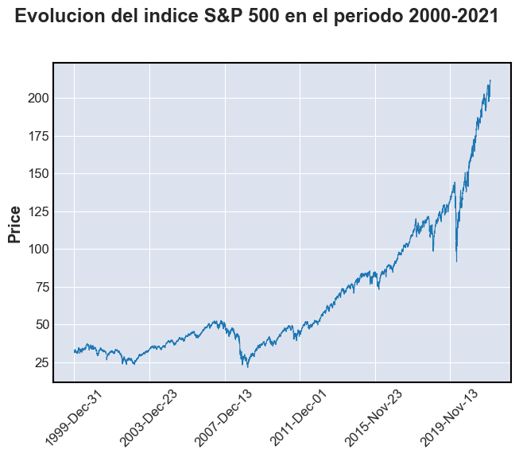

```python
datap2 = df_precios.groupby("Date").agg({ 'Open':'mean', 'High':'mean', 'Low':'mean', 'Close':'mean', 'Adj Close':'mean','Ret_Intradiario':'mean', 'Ret_Gaps':'mean'})
mpf.plot(datap2, type='line', title='Evolucion del indice S&P 500 en el periodo 2000-2021')
plt.show()
```

[figure not shown]

```python
#graficamos la evolucion del indice VIX
mpf.plot(df_VIX, type='line',title='Evolucion del indice VIX en el periodo 2000-2021')
plt.show()
```

### Cuales son las mejores industrias que pertenecen al S&P500 en las cuales se puede invertir.

#### Teniendo en cuenta los Ajustes de Cierre.

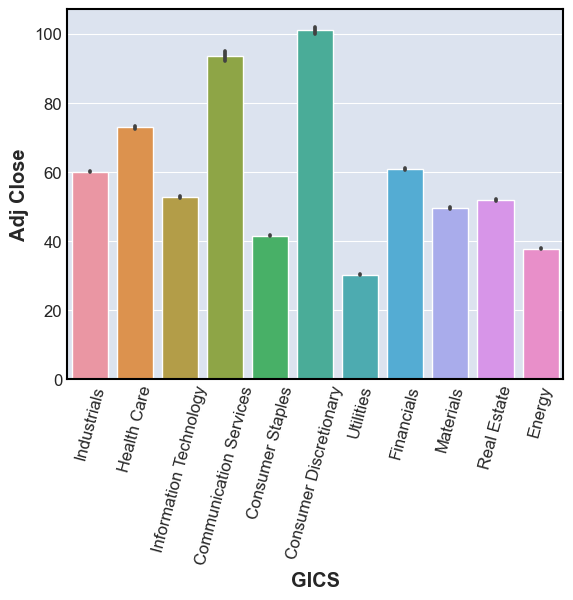

```python
#Grafico las industrias con mejor retorno intradiario
plt.xticks(fontsize=12,rotation=75)
sns.set(rc={'figure.figsize':(50,10)})
sns.barplot(data= df_precios, x = 'GICS', y = "Adj Close" )
plt.show()
```

## Cuales fueron los momentos de alta volatilidad que afectaron al S&P500.

```python
#Agrupo por dias la media de los precios
df = df_precios.groupby("Date").agg({ 'Open':'mean', 'High':'mean', 'Low':'mean', 'Close':'mean', 'Adj Close':'mean','Ret_Intradiario':'mean', 'Ret_Gaps':'mean'})

#Reseteo el indice
df.reset_index(inplace=True)
```

[figure not shown]

#### En el grafico podemos ver que la mayor volatilidad se dio en el año 2008, posiblemente por la crisis subprime, luego en septiembre del 2011 posiblemente el ataque a las torres gemelas incidio en la volatilidad y luego a principios del 2020 con el inicio de la pandemia.

```python
#Agrupo por dias la media de los precios
df = df_precios.groupby("Date").agg({ 'Open':'mean', 'High':'mean',
                                    'Low':'mean', 'Close':'mean', 'Adj Close':'mean',
                                    'Ret_Intradiario':'mean', 'Ret_Gaps':'mean'})

#Creo el indice
df.reset_index(inplace=True)
```

[figure not shown]

#### Podemos observar como la volatilidad esta directamente relacionada con las caidas de los cierres ajustados en el precio promedio de las empresas del S&P 500.